# Opportunity Zones in Fairfax County, VA

Teja Pristavec

November 28, 2019

For this task, we want to visualize all opportunity zones in Fairfax County and their neighboring tracts. [Opportunity zones](https://www.irs.gov/newsroom/opportunity-zones-frequently-asked-questions) are select low-income Census tracts eligible for investment incentives, and there are nine [within Fairfax County, VA](https://www.fairfaxcounty.gov/health-humanservices/opportunity-zones).

# 1 Getting the data

Our first step is to request Fairfax County geography from `tigris`. We look for tracts in Virginia, and for county Federal Information Processing Standard ([FIPS](https://www.census.gov/geographies/reference-files/2017/demo/popest/2017-fips.html)) code 059. We convert the object to a simple feature (`sf`).

```r
library(tigris)
library(sf)

ffxcounty <- tracts("VA", county = "059", progress_bar = FALSE)
ffxcounty <- st_as_sf(ffxcounty)
```

# 2 Identifying tracts of interest

Now that we have information on all tracts, we also want to create an indicator for opportunity zones, our tracts of interest. There are [nine in Fairfax County, VA](https://www.fairfaxcounty.gov/health-humanservices/opportunity-zones) (North Hill, Hybla Valley, Mount Vernon Woods, South County Center, Willston Center, Bailey’s North/Glen Forest, Skyline Plaza, Herndon South, and Lake Anne), and their numbers are 4810, 4821, 4514, 4515.02, 4528.01, 4154.01, 4215, 4216, and 4218.

```r
library(dplyr)

ffxcounty <- ffxcounty %>% mutate(opportunity = ifelse((NAME == 4810 |
                                                        NAME == 4821 |
                                                        NAME == 4514 |
                                                        NAME == 4515.02 |
                                                        NAME == 4528.01 |
                                                        NAME == 4154.01 |
                                                        NAME == 4215 |
                                                        NAME == 4216 |
                                                        NAME == 4218), 1, 0))
```

We’ll also need to identify neighboring tracts to compare with opportunity zones. We create an object with our zones only, and then use `st_touches` to select tracts that share any zone’s border. `st_touches` gives the result as a list, so we unlist it.

```r
# Identify zone neighbors
zones <- ffxcounty %>% filter(opportunity == 1)

neighbors <- st_touches(zones, ffxcounty, sparse = TRUE)
neighborlist <- unlist(neighbors)

# Create neighbor indicator
ffxcounty <- ffxcounty %>% mutate(id = row_number(),
                                  neighbor = ifelse(id %in% neighborlist, 1, 0))
```

# 3 Plotting zones and neighbors

Having defined our variables, we work on plotting. First, we make a test plot to make sure we’re on the right track, and convert variables to factors so they’ll be easier to work with later.

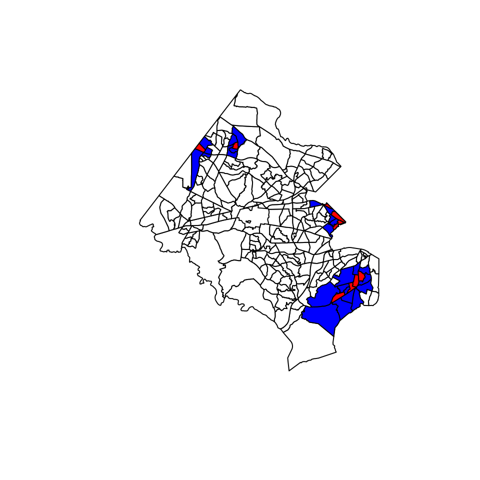

```r
# Test plot again with all indicators in same dataset
plot(st_geometry(ffxcounty), col = "white")
plot(st_geometry(ffxcounty[ffxcounty$neighbor == 1, ]), add = TRUE, col = "blue")
plot(st_geometry(ffxcounty[ffxcounty$opportunity == 1, ]), add = TRUE, col = "red")
```

```r
# Convert to factor
ffxcounty$neighbor <- as.factor(ffxcounty$neighbor)
ffxcounty$opportunity <- as.factor(ffxcounty$opportunity)
```

With our prototype done, we put some effort into aesthetics. Before plotting, we need assign coordinates for our zone labels.

```r
# Select tracts
labelzones <- ffxcounty[ffxcounty$opportunity == 1, ]
labelneighbors <- ffxcounty[ffxcounty$neighbor == 1, ]

# Get points
point_zones <- st_point_on_surface(labelzones)
point_neighbors <- st_point_on_surface(labelneighbors)

# Retrieve coordinates
coords_zone <- as.data.frame(st_coordinates(point_zones))
coords_zone$name <- point_zones$NAME

coords_neighbor <- as.data.frame(st_coordinates(point_neighbors))
coords_neighbor$name <- point_neighbors$NAME
```

We add these labels to our final plot with `geom_label_repel`.

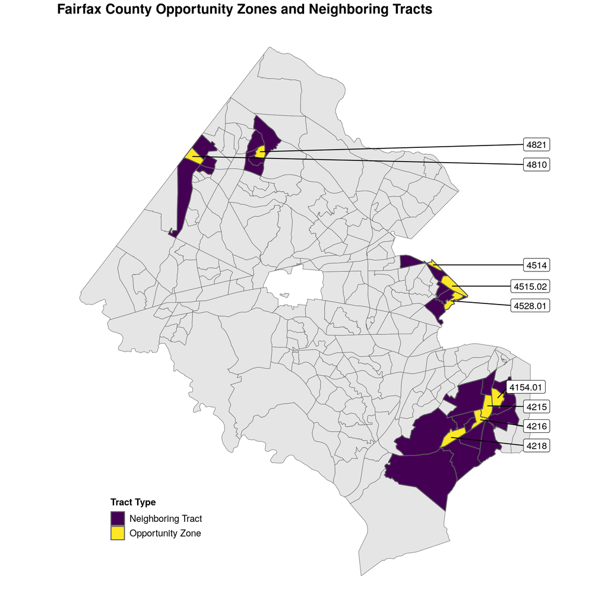

```r
library(ggplot2)
library(ggthemes)
library(ggrepel)
library(scales)

ggplot() +
  geom_sf(data = ffxcounty, size = 0.2) +
  geom_sf(data = ffxcounty[ffxcounty$neighbor == 1, ], aes(fill = "#440154")) +
  geom_sf(data = ffxcounty[ffxcounty$opportunity == 1, ], aes(fill = "#FDE725"))  +
  geom_label_repel(data = coords_zone, aes(X, Y, label = name),
                   colour = "black", nudge_x = 3, segment.size = 0.5) +
  labs(title = "Fairfax County Opportunity Zones and Neighboring Tracts") +
  theme_map() +
  theme(plot.title = element_text(size = 16, face = "bold"),
        legend.title = element_text(size = 11, face = "bold"),
        legend.text = element_text(size = 11),
        legend.position = c(0.1, 0.1)) +
  scale_fill_identity(name = "Tract Type", guide = "legend",
                      labels = c("Neighboring Tract", "Opportunity Zone"))
```